# MEDISIS Differences in Abundance

Stephanie Hopkins

2024-03-07

# Read the data and make a data frame

Here we are interested in the comparison of the model’s simulated abundance at the end of the month by age over the calibration and validation periods (2015-2019). Recall that we only have MEDITS data for the months of May and June, and for age classes 2 or less.

To access this information, go to the where the StatusQuo simulation is stored. So from the Data formation step, where all the simulations were moved into the empty folder with the simulation name, we want to chose the one ending in “_0”. So for example if my simulation name is “sim_MEDISIS_2024-02-15-09-55”, I would chose the simulation “sim_MEDISIS_2024-02-15-09-55_0”. The full path will look something like this: “C:/Users/shopkins/Documents/isis-fish-4/isis-database/simulations/sim_MEDISIS_2024-02-15-09-55_0/resultExports/Abundance_ExportEnd.csv”

```r
isis.fish_statusquo_abund.nb <- fread(paste(simFolder, StatusQuo.scen, "resultExports/Abundance_ExportEnd.csv", sep=""),sep=";")

# View(isis.fish_statusquo_abund.nb)

# Summarise the data to remove zone and ages 3 and up
# that are not well represented in MEDITS survey
isis.fish_statusquo_abund.nb <- isis.fish_statusquo_abund.nb %>%
  filter(!group %in% c(3:5)) %>%
  group_by(step, group) %>%
  summarise(value = sum(value), .groups = "keep")

# Restructure the data so that age is its own column
isis.fish_statusquo_abund.nb.wd <- isis.fish_statusquo_abund.nb %>%
  pivot_wider(names_from = "group", values_from = "value")

# View(isis.fish_statusquo_abund.nb.wd)

names(isis.fish_statusquo_abund.nb.wd) <- c("step","Age0","Age1","Age2")

step <- unique(isis.fish_statusquo_abund.nb.wd$step)
nbYear <- length(step)/12
YEAR <- sort(rep(seq(2015,2014+nbYear,1), 12))
MONTH <- rep(seq(1,12,1),nbYear)
tabStep <- data.frame(step, YEAR, MONTH)

isis.fish_statusquo_abund.nb.wd <- inner_join(isis.fish_statusquo_abund.nb.wd, tabStep, by=c('step'))
```

# Adjust values to compare

Here we need to convert number to number of thousands, and only use months corresponding to the MEDITS survey. The survey runs in late May and early June so in this study we compared simulated values within a temporal buffer range of +/- 1.5 months (April to July).

```r
# covert to number of thousands
isis.fish_statusquo_abund.nb.wd$Age0 <- as.numeric(isis.fish_statusquo_abund.nb.wd$Age0)/1000
isis.fish_statusquo_abund.nb.wd$Age1 <- as.numeric(isis.fish_statusquo_abund.nb.wd$Age1)/1000
isis.fish_statusquo_abund.nb.wd$Age2 <- as.numeric(isis.fish_statusquo_abund.nb.wd$Age2)/1000

# Subset the data to include only the months of April to July (comparable MEDITS years)
isis.fish_statusquo_abund.nb.wd.sub <- isis.fish_statusquo_abund.nb.wd %>% filter(MONTH %in% c(4:7))
isis.fish_statusquo_abund.nb.wd.sub

# Take of the mean of this quarter
isis.fish_statusquo_abund.nb.wd.sub2 <- isis.fish_statusquo_abund.nb.wd.sub %>%
  group_by(YEAR) %>%
  summarise(Age0=round(mean(Age0)), Age1=round(mean(Age1)), Age2=round(mean(Age2)))

isis.fish_statusquo_abund.nb.wd.sub2

isis.fish_statusquo_abund.nb.wd.sub2$Source <- "ISIS-Fish"

# Since we do not have data for the projected years, just use the data up to 2020
isis.fish_statusquo_abund.nb.wd.sub2.1 <- isis.fish_statusquo_abund.nb.wd.sub2 %>%
  filter(YEAR < 2020)

isis.fish_statusquo_abund.nb.wd.sub2.1$YEAR <- as.character(isis.fish_statusquo_abund.nb.wd.sub2.1$YEAR)
```

## Make a data frame of MEDITS Standard Abundance outputs

Note that from the GFCM 2019 Benchmark session for hake the data was as follows:

YEAR <- c(2015, 2016, 2017, 2018) Age0 <- c(1934, 3099, 556, 1584) Age1 <- c(202, 228, 167, 344) Age2 <- c(24, 24, 31, 13) GFCM <- data.frame(YEAR, Age0, Age1, Age2)

However, the MEDITS data used here was applied differently.

Therefore we first load standard abundance values derived from the MEDITS data.

## Load MEDITS aggregations from official data set

Here we are using an aggregation internally used.

```r
load(paste(path,"Data/MEDITS/Abundance Indices/MERLMER_N_MEDITS.Rdata",sep=""))

# Restructure the data
MERLMER_N_MEDITS.long <- as.data.frame(MERLMER_N_MEDITS) %>%
  mutate(YEAR = row.names(MERLMER_N_MEDITS)) %>%
  pivot_longer(!YEAR, names_to = "LENGTH_CLASS", values_to = "StanAbund")

#View(MERLMER_N_MEDITS.long)

# Filter the data to match our data set ranges
MERLMER_N_MEDITS.long2 <- MERLMER_N_MEDITS.long %>%
  filter(YEAR %in% c(2015:2019))
```

# Compute Age

Standard practice in the Gulf of Lion is to use an asymptotic growth curve to represent the mean length to age relationship last identified by Mellon-Duval et al., 2010. This growth curve does not take sex specific growth trends or environmental conditions into account. In order to compare the standard abundance at age, we bin on lengths corresponding to a specific age in years. Note that we do not have many observations from age classes 3 and up so these will be filtered out.

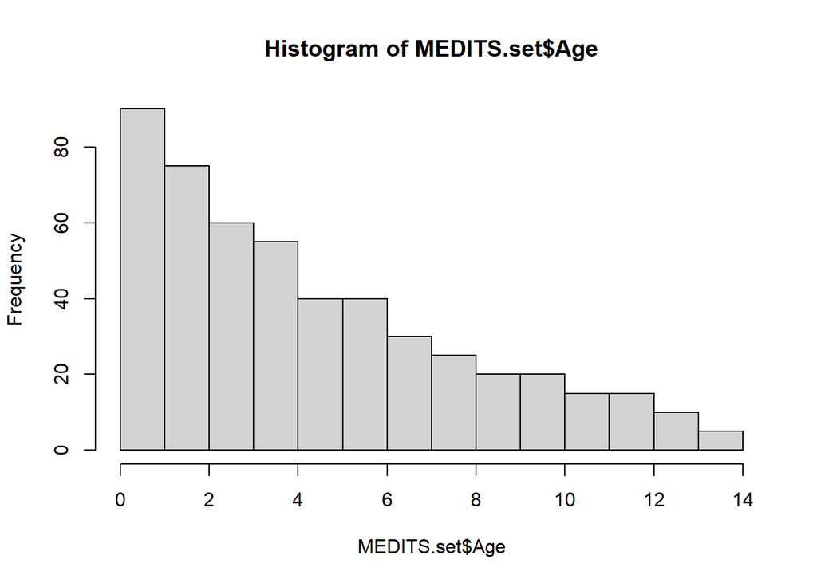

```r
MERLMER_N_MEDITS.long2 <- mutate(MERLMER_N_MEDITS.long2,
                                 Age = (1/-0.178)*log(1-(as.numeric(LENGTH_CLASS)/110)))

range(MERLMER_N_MEDITS.long2$Age)
# [1]  0.05130609 13.47132176

MEDITS.set <- MERLMER_N_MEDITS.long2[!is.nan(MERLMER_N_MEDITS.long2$Age),]

range(MEDITS.set$Age)
# [1]  0.05130609 13.47132176

MEDITS.set$Age <- round(MEDITS.set$Age, digits = 2)

hist(MEDITS.set$Age)
```

```r
str(MEDITS.set)
summary(MEDITS.set)

# Test distribution
Ages2 <- MEDITS.set$Age
ks.test(Ages2, "pnorm")
#   Asymptotic one-sample Kolmogorov-Smirnov test
# data:  Ages
# D = 0.68663, p-value < 2.2e-16
# alternative hypothesis: two-sided

MEDITS.set2 <- MEDITS.set

MEDITS.set2.1_0 <- filter(MEDITS.set2, Age < 1)
MEDITS.set2.1_0$Age_group <- "Age0"

MEDITS.set2.1_1 <- filter(MEDITS.set2, Age > 0.99 & Age < 2)
MEDITS.set2.1_1$Age_group <- "Age1"

MEDITS.set2.1_2 <- filter(MEDITS.set2, Age > 1.99 & Age < 3)
MEDITS.set2.1_2$Age_group <- "Age2"

MEDITS.set2.1_3plus <- filter(MEDITS.set2, Age > 2.99)
MEDITS.set2.1_3plus$Age_group <- "Age3plus"

MEDITS.set2.2 <- rbind(MEDITS.set2.1_0, MEDITS.set2.1_1, MEDITS.set2.1_2, MEDITS.set2.1_3plus)

# Convert to number of thousands
MEDITS.set2.2$StandAbund <- MEDITS.set2.2$StanAbund/1000

MEDITS.set2.2.agg <- aggregate(StandAbund ~ YEAR + Age_group, FUN=sum, data=MEDITS.set2.2)

fwrite(MEDITS.set2.2.agg, file=paste(path,"Data/compare_standabund_isis.csv", sep=""), sep=";")
```

# Load Aggregated MEDITS Data

Here we are just restructuring the data.

```r
MEDITS.set3 <- fread(paste(path,"Data/compare_standabund_isis.csv", sep=""), sep=";")
View(MEDITS.set3)

# Restructure the data to match the ISIS-Fish data.frame
Age0 <- MEDITS.set3 %>%
  filter(Age_group == "Age0") %>%
  pivot_wider(names_from = "Age_group", values_from = "StandAbund")

# Restructure the data to match the ISIS-Fish data.frame
Age1 <- MEDITS.set3 %>%
  filter(Age_group == "Age1") %>%
  pivot_wider(names_from = "Age_group", values_from = "StandAbund")

# Restructure the data to match the ISIS-Fish data.frame
Age2 <- MEDITS.set3 %>%
  filter(Age_group == "Age2") %>%
  pivot_wider(names_from = "Age_group", values_from = "StandAbund")

MEDITS_standabund2 <- inner_join(Age0, Age1, by="YEAR")

MEDITS_standabund2.1 <- inner_join(MEDITS_standabund2, Age2, by="YEAR")

MEDITS_standabund2.1$Source <- "MEDITS"
MEDITS_standabund2.1
```

# Compare outputs

Join the two dataframes and restructure the data once more.

```r
final.data <- rbind(isis.fish_statusquo_abund.nb.wd.sub2.1, MEDITS_standabund2.1)

melt.final.data <- reshape2::melt(final.data, id=c("YEAR", "Source"))
```

# Make your life easy and save custom themes

```r
bar_chart_text_theme <- theme(axis.title.x = element_text(margin=margin(t=5,r=0,b=0,l=0), size = 12), axis.text.y = element_text(margin=margin(t=0,r=0,b=0,l=5), size = 10), axis.text.x.bottom = element_text(margin=margin(t=10,r=0,b=0,l=0), size = 10, angle = 65), axis.title.y = element_text(size = 12), strip.text = element_text(size=10), panel.spacing = unit(0.5, "cm"))

bar_chart_legend_theme <- theme(legend.title = element_blank(), legend.text = element_text(size = 10),legend.text.align = 0, legend.direction = "horizontal", legend.spacing = unit(0.001, 'cm'), legend.key.height = unit(1.52, 'cm'), legend.key.width = unit(1.5, 'cm'), legend.position="bottom")
```

# Plot outputs

## Apendix Fig. D.1

For comparable age classes (i.e., ages 0, 1, & 2), we compare simulated vs observed abundance values in number per thousands.

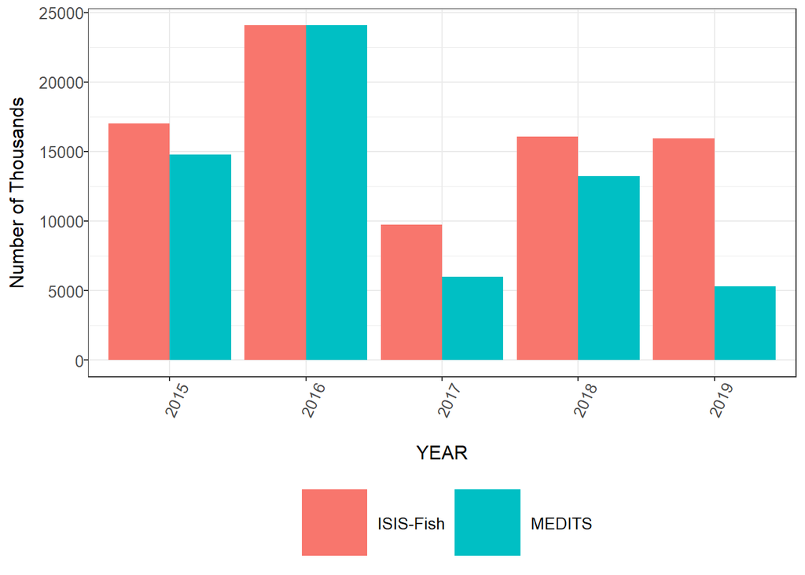

```r
melt.final.data2 <- melt.final.data %>% group_by(YEAR, Source) %>% summarise(value.all=sum(value))

Validationplot_ALL <- ggplot(data=melt.final.data2, aes(x=YEAR, y=value.all, fill=Source))+
  geom_bar(stat="identity", position=position_dodge())+
  ylab("Number of Thousands")+
  theme_bw()+
  bar_chart_text_theme+
  bar_chart_legend_theme+
  guides(fill = guide_legend(byrow = TRUE))

Validationplot_ALL
```

## Apendix Fig. D.2

For Age 0 specifically (i.e., recruits), we compare simulated vs observed abundance values in number per thousands.

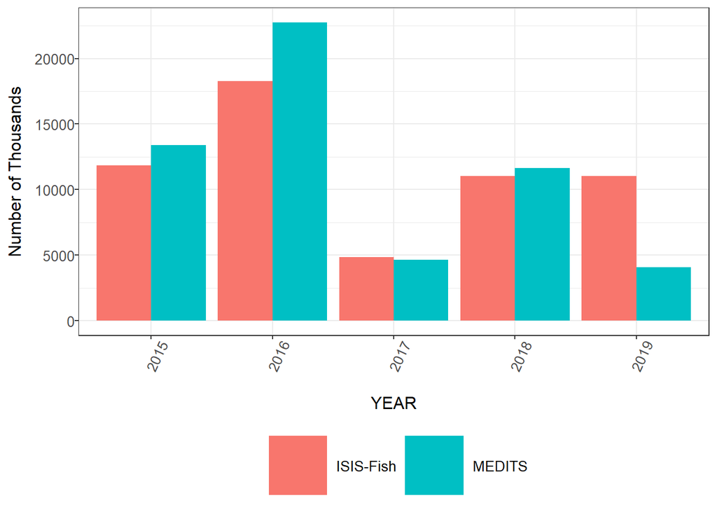

```r
Validationplot_age0 <- ggplot(data=melt.final.data[melt.final.data$variable=="Age0", ], aes(x=YEAR, y=value, fill=Source))+
  geom_bar(stat="identity", position=position_dodge())+
  ylab("Number of Thousands")+
  theme_bw()+
  bar_chart_text_theme+
  bar_chart_legend_theme+
  guides(fill = guide_legend(byrow = TRUE))

Validationplot_age0
```